# Project for nycflights13 Dataset Analysis

# **Exploratory Data Analysis**:

We performed initial exploratory analysis to understand the distribution and relationships between key variables.

## **Summary Statistics**:

```r
summary(flights)
##       year          month             day           dep_time    sched_dep_time
##  Min.   :2013   Min.   : 1.000   Min.   : 1.00   Min.   :   1   Min.   : 106
##  1st Qu.:2013   1st Qu.: 4.000   1st Qu.: 8.00   1st Qu.: 907   1st Qu.: 906
##  Median :2013   Median : 7.000   Median :16.00   Median :1401   Median :1359
##  Mean   :2013   Mean   : 6.549   Mean   :15.71   Mean   :1349   Mean   :1344
##  3rd Qu.:2013   3rd Qu.:10.000   3rd Qu.:23.00   3rd Qu.:1744   3rd Qu.:1729
##  Max.   :2013   Max.   :12.000   Max.   :31.00   Max.   :2400   Max.   :2359
##                                                  NA's   :8255
##    dep_delay          arr_time    sched_arr_time   arr_delay
##  Min.   : -43.00   Min.   :   1   Min.   :   1   Min.   : -86.000
##  1st Qu.:  -5.00   1st Qu.:1104   1st Qu.:1124   1st Qu.: -17.000
##  Median :  -2.00   Median :1535   Median :1556   Median :  -5.000
##  Mean   :  12.64   Mean   :1502   Mean   :1536   Mean   :   6.895
##  3rd Qu.:  11.00   3rd Qu.:1940   3rd Qu.:1945   3rd Qu.:  14.000
##  Max.   :1301.00   Max.   :2400   Max.   :2359   Max.   :1272.000
##  NA's   :8255      NA's   :8713                  NA's   :9430
##    carrier              flight       tailnum             origin
##  Length:336776      Min.   :   1   Length:336776      Length:336776
##  Class :character   1st Qu.: 553   Class :character   Class :character
##  Mode  :character   Median :1496   Mode  :character   Mode  :character
##                     Mean   :1972
##                     3rd Qu.:3465
##                     Max.   :8500
##
##      dest              air_time        distance         hour
##  Length:336776      Min.   : 20.0   Min.   :  17   Min.   : 1.00
##  Class :character   1st Qu.: 82.0   1st Qu.: 502   1st Qu.: 9.00
##  Mode  :character   Median :129.0   Median : 872   Median :13.00
##                     Mean   :150.7   Mean   :1040   Mean   :13.18
##                     3rd Qu.:192.0   3rd Qu.:1389   3rd Qu.:17.00
##                     Max.   :695.0   Max.   :4983   Max.   :23.00
##                     NA's   :9430
##      minute        time_hour
##  Min.   : 0.00   Min.   :2013-01-01 05:00:00.00
##  1st Qu.: 8.00   1st Qu.:2013-04-04 13:00:00.00
##  Median :29.00   Median :2013-07-03 10:00:00.00
##  Mean   :26.23   Mean   :2013-07-03 05:22:54.64
##  3rd Qu.:44.00   3rd Qu.:2013-10-01 07:00:00.00
##  Max.   :59.00   Max.   :2013-12-31 23:00:00.00
##
glimpse(flights)
## Rows: 336,776
## Columns: 19
## $ year           <int> 2013, 2013, 2013, 2013, 2013, 2013, 2013, 2013, 2013, 2…
## $ month          <int> 1, 1, 1, 1, 1, 1, 1, 1, 1, 1, 1, 1, 1, 1, 1, 1, 1, 1, 1…
## $ day            <int> 1, 1, 1, 1, 1, 1, 1, 1, 1, 1, 1, 1, 1, 1, 1, 1, 1, 1, 1…
## $ dep_time       <int> 517, 533, 542, 544, 554, 554, 555, 557, 557, 558, 558, …
## $ sched_dep_time <int> 515, 529, 540, 545, 600, 558, 600, 600, 600, 600, 600, …
## $ dep_delay      <dbl> 2, 4, 2, -1, -6, -4, -5, -3, -3, -2, -2, -2, -2, -2, -1…
## $ arr_time       <int> 830, 850, 923, 1004, 812, 740, 913, 709, 838, 753, 849,…
## $ sched_arr_time <int> 819, 830, 850, 1022, 837, 728, 854, 723, 846, 745, 851,…
## $ arr_delay      <dbl> 11, 20, 33, -18, -25, 12, 19, -14, -8, 8, -2, -3, 7, -1…
## $ carrier        <chr> "UA", "UA", "AA", "B6", "DL", "UA", "B6", "EV", "B6", "…
## $ flight         <int> 1545, 1714, 1141, 725, 461, 1696, 507, 5708, 79, 301, 4…
## $ tailnum        <chr> "N14228", "N24211", "N619AA", "N804JB", "N668DN", "N394…
## $ origin         <chr> "EWR", "LGA", "JFK", "JFK", "LGA", "EWR", "EWR", "LGA",…
## $ dest           <chr> "IAH", "IAH", "MIA", "BQN", "ATL", "ORD", "FLL", "IAD",…
## $ air_time       <dbl> 227, 227, 160, 183, 116, 150, 158, 53, 140, 138, 149, 1…
## $ distance       <dbl> 1400, 1416, 1089, 1576, 762, 719, 1065, 229, 944, 733, …
## $ hour           <dbl> 5, 5, 5, 5, 6, 5, 6, 6, 6, 6, 6, 6, 6, 6, 6, 5, 6, 6, 6…
## $ minute         <dbl> 15, 29, 40, 45, 0, 58, 0, 0, 0, 0, 0, 0, 0, 0, 0, 59, 0…
## $ time_hour      <dttm> 2013-01-01 05:00:00, 2013-01-01 05:00:00, 2013-01-01 0…
```

## **Distribution of Arrival Delays**:

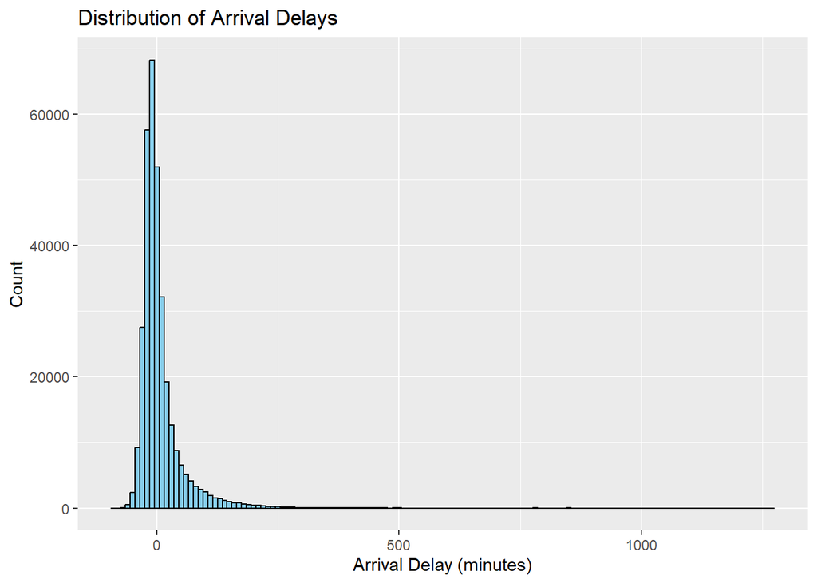

```r
library(ggplot2)

# Plotting the distribution of arrival delays
flights %>%
  filter(!is.na(arr_delay)) %>%
  ggplot(aes(x = arr_delay)) +
  geom_histogram(binwidth = 10, fill = "skyblue", color = "black") +
  labs(title = "Distribution of Arrival Delays", x = "Arrival Delay (minutes)", y = "Count")
```

## **Comparison of Delays by Airline**:

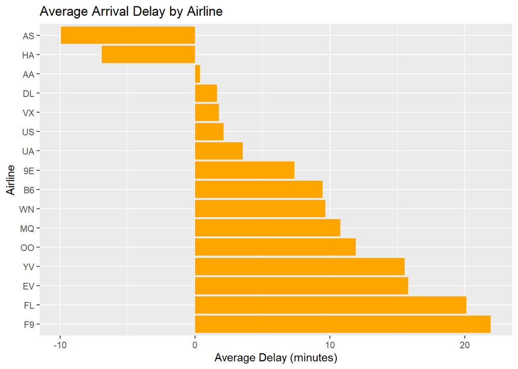

```r
# Bar plot showing average arrival delay by airline
flights %>%
  filter(!is.na(arr_delay)) %>%
  group_by(carrier) %>%
  summarise(mean_arr_delay = mean(arr_delay, na.rm = TRUE)) %>%
  ggplot(aes(x = reorder(carrier, -mean_arr_delay), y = mean_arr_delay)) +
  geom_bar(stat = "identity", fill = "orange") +
  labs(title = "Average Arrival Delay by Airline", x = "Airline", y = "Average Delay (minutes)") +
  coord_flip()
```

## **Delays by Month**:

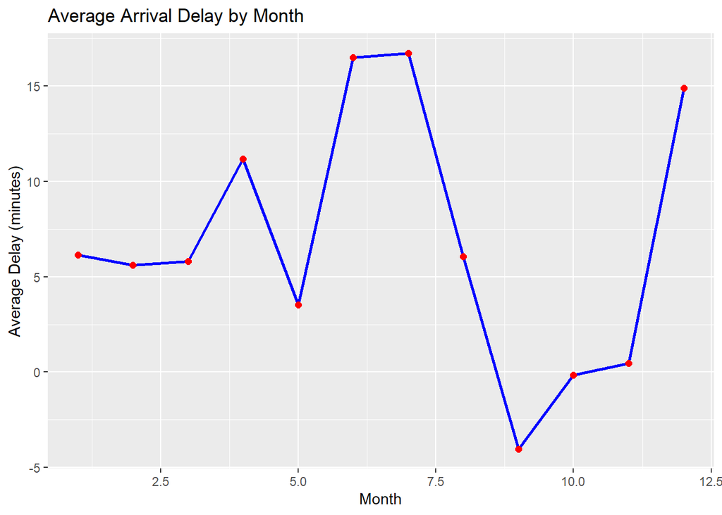

```r
# Time series plot of average delays by month
flights %>%
  filter(!is.na(arr_delay)) %>%
  group_by(month) %>%
  summarise(avg_arr_delay = mean(arr_delay, na.rm = TRUE)) %>%
  ggplot(aes(x = month, y = avg_arr_delay)) +
  geom_line(color = "blue", size = 1) +
  geom_point(color = "red", size = 2) +
  labs(title = "Average Arrival Delay by Month", x = "Month", y = "Average Delay (minutes)")
## Warning: Using `size` aesthetic for lines was deprecated in ggplot2 3.4.0.
## ℹ Please use `linewidth` instead.
## This warning is displayed once every 8 hours.
## Call `lifecycle::last_lifecycle_warnings()` to see where this warning was
## generated.
```

## **Data Cleaning**:

The dataset contains some missing and erroneous values, particularly in columns related to delays and times. We plan to clean the data by:

- Removing rows with missing `dep_delay` or `arr_delay` values.
- Filtering out flights with extreme outliers in delay times.

## **Methodology**:

To answer the research questions, we will employ the following methods:

1. **Descriptive Analysis:** Summary statistics and visualizations to understand trends and distributions.
2. **Correlation Analysis:** Identifying relationships between variables such as distance, delay, and carrier.
3. **Time Series Analysis:** Examining seasonal and daily patterns in flight delays.
4. **Predictive Modeling:**
- We plan to build regression and classification models to predict delays.
- Models may include linear regression, decision trees, and random forests.

### Example Correlation Analysis:

```r
# Calculate correlation between distance and arrival delay
correlation <- cor(flights$distance, flights$arr_delay, use = "complete.obs")
cat("Correlation between flight distance and arrival delay: ", correlation)
## Correlation between flight distance and arrival delay:  -0.06186776
```

## How do departure times impact delays?

```r
flights_C <- flights %>%
  drop_na()
```

```r
flights_1 <- flights %>%
  slice(1:50000) %>%
  drop_na(dep_time, dep_delay) %>%
  mutate(
    dep_time_decimal = (dep_time %/% 100) + (dep_time %% 100) / 60)
```

## 6. Data Exploration and Visualization:

Our dataset includes historical flight records, which we analyze to understand delay trends. Key visualizations and statistics from our exploratory data analysisbinclude:

Impact of Departure Time on Delays 7

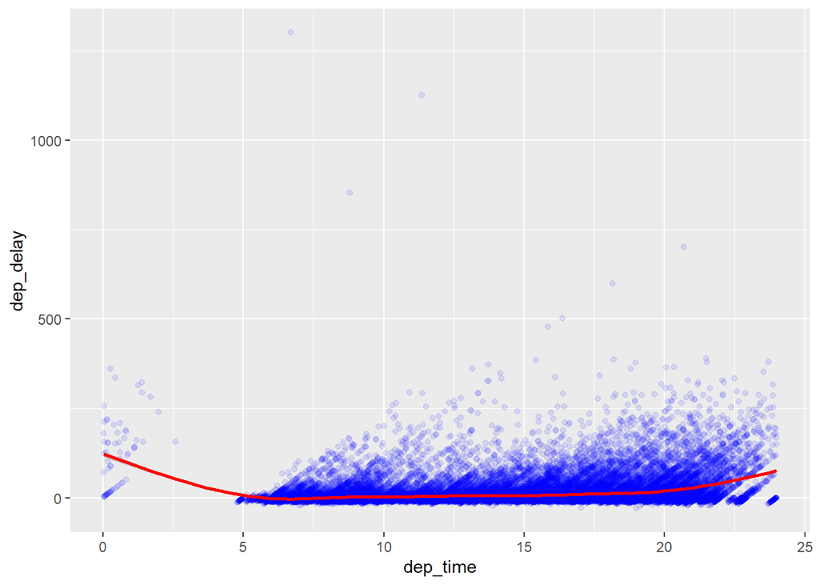

```r
ggplot(flights_1, aes(x = dep_time_decimal, y = dep_delay)) +
  geom_point(alpha = 0.1, col = "blue") +
  geom_smooth(col = "red") +
  labs (x = "dep_time")
```

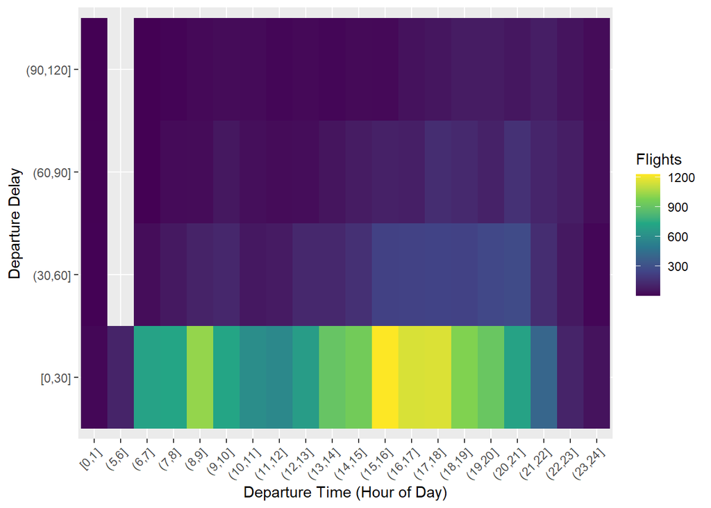

```r
flights_d <- flights |>
  slice(1:50000) |>
  drop_na(dep_time, dep_delay) |>
  filter(dep_delay >= 0) |>
  mutate(
    dep_time_decimal = (dep_time %/% 100) + (dep_time %% 100) / 60,
    time_bin = cut(dep_time_decimal, breaks = seq(0, 24, by = 1), include.lowest = TRUE),
    delay_bin = cut(dep_delay, breaks = seq(0, 120, by = 30), include.lowest = TRUE)
  ) |>
  # Remove rows with NA in bins (e.g., delays >120 minutes or edge cases)
  filter(!is.na(time_bin), !is.na(delay_bin)) |>
  group_by(time_bin, delay_bin) |>
  summarise(count = n(), .groups = "drop")

ggplot(flights_d, aes(x = time_bin, y = delay_bin, fill = count)) +
  geom_tile() +
  scale_fill_viridis_c(option = "viridis", name = "Flights") +
  labs(x = "Departure Time (Hour of Day)", y = "Departure Delay") +
  theme(axis.text.x = element_text(angle = 45, hjust = 1))
```

```r
flights_r <- flights %>%
  slice(1000:5000) %>%
  drop_na(dep_time, dep_delay) %>%
  mutate(dep_hour = dep_time %/% 100)

modeldh <- lm(dep_delay ~ dep_time + (dep_time^2), data = flights_r)


summary(modeldh)
```

```
##
## Call:
## lm(formula = dep_delay ~ dep_time + (dep_time^2), data = flights_r)
##
## Residuals:
##    Min     1Q Median     3Q    Max
## -38.64 -14.08  -7.37   0.49 359.48
##
## Coefficients:
##              Estimate Std. Error t value Pr(>|t|)
## (Intercept) -7.444534   1.480065   -5.03 5.13e-07 ***
## dep_time     0.012655   0.001033   12.25  < 2e-16 ***
## ---
## Signif. codes:  0 '***' 0.001 '**' 0.01 '*' 0.05 '.' 0.1 ' ' 1
##
## Residual standard error: 29.84 on 3972 degrees of freedom
## Multiple R-squared:  0.03643,    Adjusted R-squared:  0.03619
## F-statistic: 150.2 on 1 and 3972 DF,  p-value: < 2.2e-16
```

```r
flights_a <- flights %>%
  slice(1000:5000) %>%
  drop_na(dep_time, arr_delay) %>%
  mutate(dep_hour = dep_time %/% 100)

modeldd <- lm(arr_delay ~ dep_time + (dep_time^2), data = flights_a)


summary(modeldd)
```

```
##
## Call:
## lm(formula = arr_delay ~ dep_time + (dep_time^2), data = flights_a)
##
## Residuals:
##    Min     1Q Median     3Q    Max
## -71.03 -18.04  -5.67   8.94 361.58
##
## Coefficients:
##              Estimate Std. Error t value Pr(>|t|)
## (Intercept) -8.485420   1.686119  -5.033 5.06e-07 ***
## dep_time     0.009272   0.001177   7.877 4.31e-15 ***
## ---
## Signif. codes:  0 '***' 0.001 '**' 0.01 '*' 0.05 '.' 0.1 ' ' 1
##
## Residual standard error: 33.96 on 3960 degrees of freedom
## Multiple R-squared:  0.01542,    Adjusted R-squared:  0.01518
## F-statistic: 62.04 on 1 and 3960 DF,  p-value: 4.315e-15
```

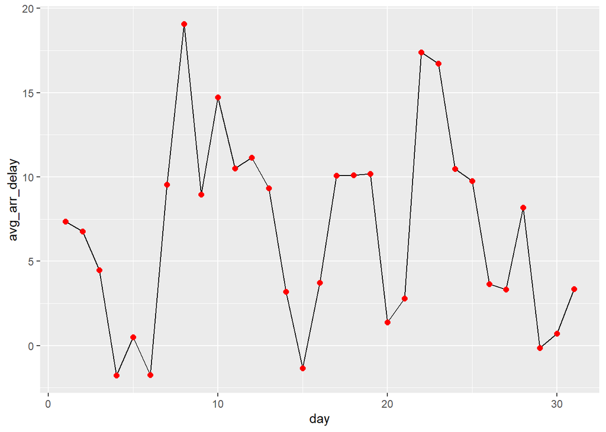

```r
flights %>%
  filter(!is.na(arr_delay)) %>%
  group_by(day) %>%
  summarise(avg_arr_delay = mean(arr_delay, na.rm = TRUE)) %>%
  ggplot(aes(x = day, y = avg_arr_delay)) +
  geom_line() +
  geom_point(color = "red", size = 2)
```

```r
flights_r <- flights %>%
  slice(1000:5000) %>%
  drop_na(dep_time, arr_delay) %>%
  mutate(dep_hour = dep_time %/% 100)

modeldr <- lm(arr_delay ~ dep_time + (dep_time^2), data = flights_r)


summary(modeldr)
```

```
##
## Call:
## lm(formula = arr_delay ~ dep_time + (dep_time^2), data = flights_r)
##
## Residuals:
##    Min     1Q Median     3Q    Max
## -71.03 -18.04  -5.67   8.94 361.58
##
## Coefficients:
##              Estimate Std. Error t value Pr(>|t|)
## (Intercept) -8.485420   1.686119  -5.033 5.06e-07 ***
## dep_time     0.009272   0.001177   7.877 4.31e-15 ***
## ---
## Signif. codes:  0 '***' 0.001 '**' 0.01 '*' 0.05 '.' 0.1 ' ' 1
##
## Residual standard error: 33.96 on 3960 degrees of freedom
## Multiple R-squared:  0.01542,    Adjusted R-squared:  0.01518
## F-statistic: 62.04 on 1 and 3960 DF,  p-value: 4.315e-15
```

# **Potential Visualizations**:

- Scatter plots of delays vs. flight distance.
- Time series plots showing average delays by month.
- Bar plots comparing delays by carrier and destination.

# **Alternative Strategies / Backup Plans**:

If our initial analysis does not yield conclusive results, we will consider the following alternative strategies:

1. **Focus on Weather Data:** Integrate external weather data to explore its impact on delays.
- Collect historical weather data for NYC in 2013.
- Analyze how weather conditions (e.g., storms, visibility) affect delays.
2. **Airline Performance Comparison:**
- Concentrate on ranking airlines based on delay metrics.
- Perform detailed case studies on the top-performing and worst-performing airlines.
3. **Airport-Specific Analysis:**
- Analyze each NYC airport separately to identify unique patterns.
- Examine how traffic congestion and infrastructure influence delays.

# **Expected Outcomes**:

We expect to uncover significant patterns in flight delays that could inform decision-making for airlines and airports. Predictive models should help stakeholders anticipate delays and improve operational efficiency.

# **Conclusion**:

This project will provide a comprehensive analysis of the `nycflights13` dataset. By answering the research questions through a combination of exploratory data analysis, visualization, and modeling, we aim to generate valuable insights into flight performance and delays. The findings will be shared in the final project report and presentation.

```r
# Final steps: Displaying key results summary
cat("Proposal complete. Next steps involve deeper analysis and model implementation.")
## Proposal complete. Next steps involve deeper analysis and model implementation.
```

## **Objective and Research Questions**:

```r
# Clearly define the objective
cat("### Objective: \n",
    "The objective of this study is to analyze flight delays using the NYCFlights13 dataset. Our research aims to:\n",
    "1. Identify key factors influencing flight delays, such as departure time, airline performance, and weather conditions.\n",
    "2. Provide insights that can help airlines optimize scheduling and improve on-time performance.\n",
    "3. Assist passengers in making informed travel decisions by understanding patterns of delays.\n",
    "4. Lay the groundwork for predictive modeling of flight delays, which can aid in operational planning for airlines and airports.\n")
```

```
## ### Objective:
##  The objective of this study is to analyze flight delays using the NYCFlights13 dataset. Our research aims to:
##  1. Identify key factors influencing flight delays, such as departure time, airline performance, and weather conditions.
##  2. Provide insights that can help airlines optimize scheduling and improve on-time performance.
##  3. Assist passengers in making informed travel decisions by understanding patterns of delays.
##  4. Lay the groundwork for predictive modeling of flight delays, which can aid in operational planning for airlines and airports.
```

## **Exploratory Data Analysis (EDA)**:

### **1. Distribution of Delays**

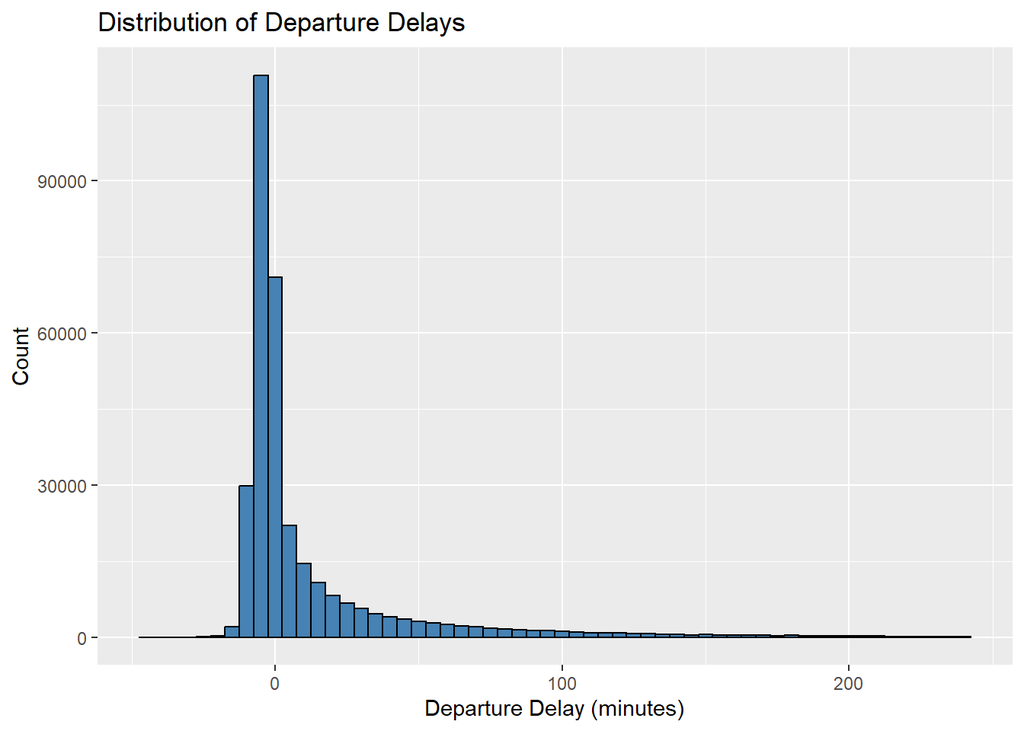

```r
flights %>%
  filter(dep_delay < 240, arr_delay < 240) %>%  # Removing extreme outliers
  ggplot(aes(x = dep_delay)) +
  geom_histogram(binwidth = 5, fill = "steelblue", color = "black") +
  labs(title = "Distribution of Departure Delays", x = "Departure Delay (minutes)", y = "Count")
```

### **2. Delays by Time of Day**

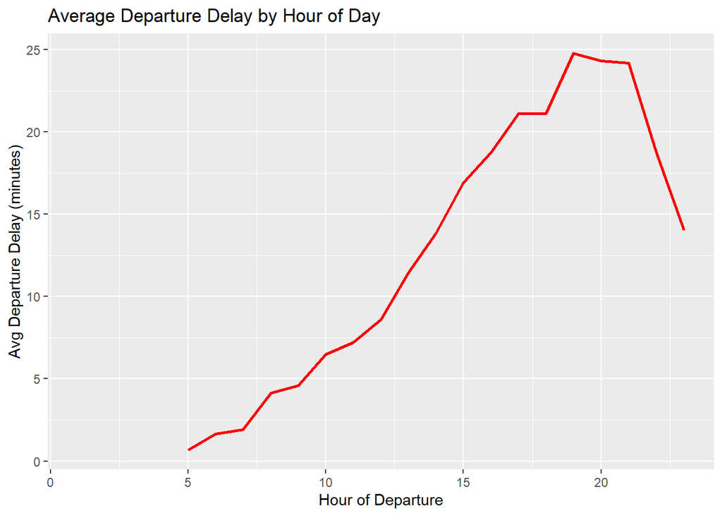

```r
flights %>%
  mutate(sched_dep_time = sprintf("%04d", sched_dep_time),  # Convert to string with 4 digits
         sched_dep_time = paste0(substr(sched_dep_time, 1, nchar(sched_dep_time) - 2), ":",
                                 substr(sched_dep_time, nchar(sched_dep_time) - 1, nchar(sched_dep_time))),  # Convert HHMM to HH:MM
         dep_hour = as.numeric(substr(sched_dep_time, 1, 2))) %>%  # Extract only the hour
  group_by(dep_hour) %>%
  summarise(mean_dep_delay = mean(dep_delay, na.rm = TRUE)) %>%
  ggplot(aes(x = dep_hour, y = mean_dep_delay)) +
  geom_line(color = "red", size = 1) +
  labs(title = "Average Departure Delay by Hour of Day", x = "Hour of Departure", y = "Avg Departure Delay (minutes)")
```

### **3. Impact of Weather on Delays**

```r
# Joining with weather data
weather_flights <- flights %>%
  inner_join(weather, by = c("year", "month", "day", "origin"))
```

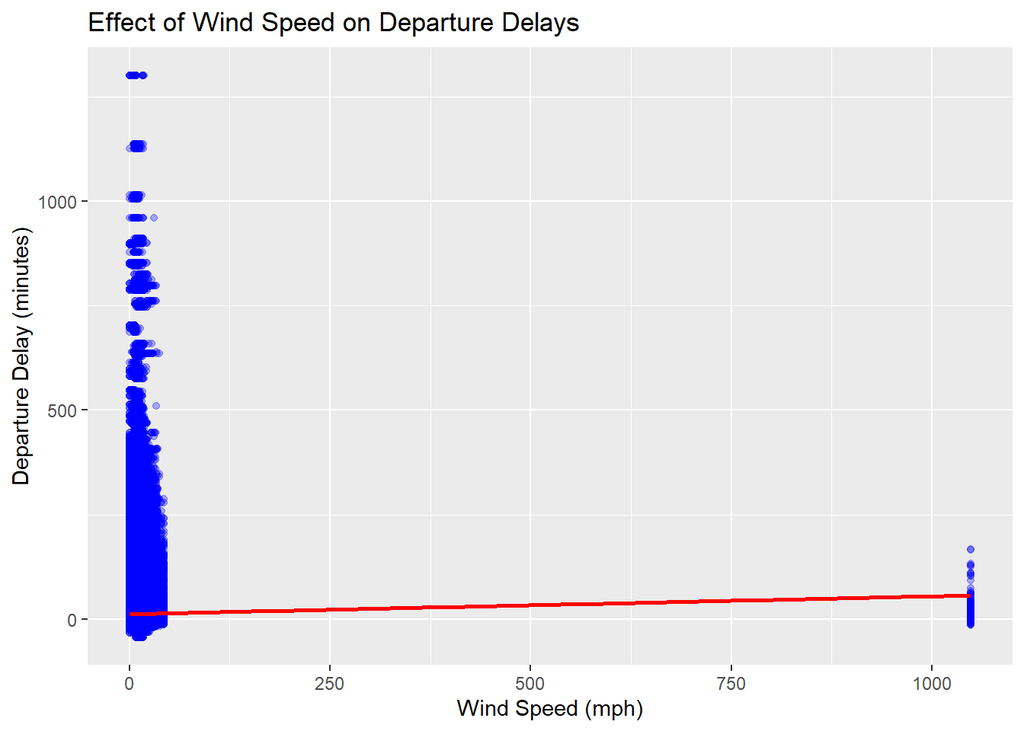

```r
# Scatter plot of wind speed vs delay
weather_flights %>%
  ggplot(aes(x = wind_speed, y = dep_delay)) +
  geom_point(alpha = 0.3, color = "blue") +
  geom_smooth(method = "lm", se = FALSE, color = "red") +
  labs(title = "Effect of Wind Speed on Departure Delays", x = "Wind Speed (mph)", y = "Departure Delay (minutes)")
```

## **7. Airport Performance Analysis We identified the airports with the highest average departure delays:**

### **Top Airports with Highest Delays**

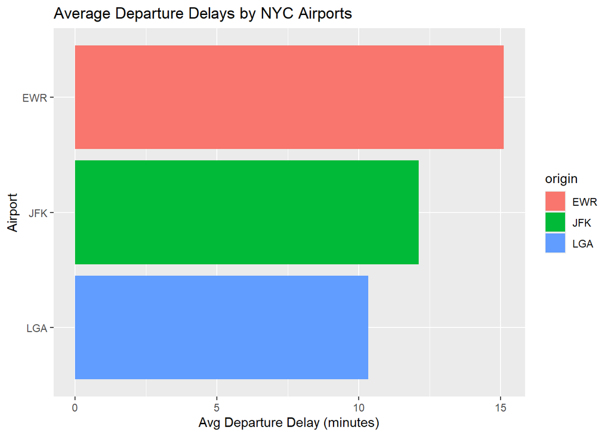

```r
flights %>%
  group_by(origin) %>%
  summarise(mean_dep_delay = mean(dep_delay, na.rm = TRUE)) %>%
  arrange(desc(mean_dep_delay)) %>%
  ggplot(aes(x = reorder(origin, mean_dep_delay), y = mean_dep_delay, fill = origin)) +
  geom_col() +
  coord_flip() +
  labs(title = "Average Departure Delays by NYC Airports", x = "Airport", y = "Avg Departure Delay (minutes)")
```

## **8. Airline Performance Analysis We analyzed arrival and departure delays by airline:**

### **5. Airline Performance**

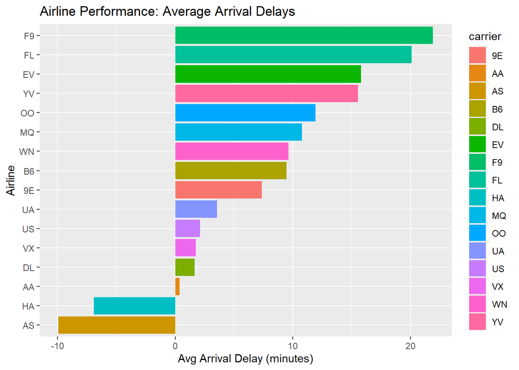

```r
flights %>%
  group_by(carrier) %>%
  summarise(mean_arr_delay = mean(arr_delay, na.rm = TRUE)) %>%
  ggplot(aes(x = reorder(carrier, mean_arr_delay), y = mean_arr_delay, fill = carrier)) +
  geom_col() +
  coord_flip() +
  labs(title = "Airline Performance: Average Arrival Delays", x = "Airline", y = "Avg Arrival Delay (minutes)")
```

## **9. Data Analysis, Modeling, and Predictions**

Potential Machine Learning Approaches To improve prediction accuracy, we plan to implement:

- Random Forest Regression: Captures complex relationships and interactions.
- Gradient Boosting Machines (GBM): Efficiently handles non-linear dependencies.
- Neural Networks: Could improve performance with sufficient data.

## **Hypothesis Testing**

### **1. Does Departure Time Affect Delays?**

**Hypothesis:**

- $H_0$: Departure time has no impact on delays.
- $H_A$: Departure time significantly impacts delays.

```r
flights_transformed <- flights %>%
  mutate(sched_dep_time = sprintf("%04d", sched_dep_time),  # Convert to string with 4 digits
         sched_dep_time = paste0(substr(sched_dep_time, 1, nchar(sched_dep_time) - 2), ":",
                                 substr(sched_dep_time, nchar(sched_dep_time) - 1, nchar(sched_dep_time))),  # Convert HHMM to HH:MM
         dep_hour = as.numeric(substr(sched_dep_time, 1, 2)))  # Extract only the hour

# Now run the model on `flights_transformed`
model <- lm(dep_delay ~ dep_hour, data = flights_transformed)
summary(model)
```

```
##
## Call:
## lm(formula = dep_delay ~ dep_hour, data = flights_transformed)
##
## Residuals:
##     Min      1Q  Median      3Q     Max
##  -69.08  -18.24   -9.68   -0.66 1295.45
##
## Coefficients:
##             Estimate Std. Error t value Pr(>|t|)
## (Intercept) -9.83761    0.20574  -47.82   <2e-16 ***
## dep_hour     1.71018    0.01475  115.92   <2e-16 ***
## ---
## Signif. codes:  0 '***' 0.001 '**' 0.01 '*' 0.05 '.' 0.1 ' ' 1
##
## Residual standard error: 39.41 on 328519 degrees of freedom
##   (8255 observations deleted due to missingness)
## Multiple R-squared:  0.03929,    Adjusted R-squared:  0.03929
## F-statistic: 1.344e+04 on 1 and 328519 DF,  p-value: < 2.2e-16
```

### **2. Does Weather Affect Delays?**

**Hypothesis:**

- $H_0$: Weather variables do not significantly impact flight delays.
- $H_A$: Weather variables significantly impact flight delays.

```r
model_weather <- lm(dep_delay ~ wind_speed + precip + temp, data = weather_flights)
summary(model_weather)
```

```
##
## Call:
## lm(formula = dep_delay ~ wind_speed + precip + temp, data = weather_flights)
##
## Residuals:
##     Min      1Q  Median      3Q     Max
## -117.26  -17.69  -13.61   -1.63 1291.85
##
## Coefficients:
##              Estimate Std. Error t value Pr(>|t|)
## (Intercept) 4.724e+00  5.210e-02   90.66   <2e-16 ***
## wind_speed  5.659e-02  1.648e-03   34.34   <2e-16 ***
## precip      7.295e+01  4.792e-01  152.24   <2e-16 ***
## temp        1.263e-01  8.151e-04  154.92   <2e-16 ***
## ---
## Signif. codes:  0 '***' 0.001 '**' 0.01 '*' 0.05 '.' 0.1 ' ' 1
##
## Residual standard error: 40.12 on 7836942 degrees of freedom
##   (198853 observations deleted due to missingness)
## Multiple R-squared:  0.006169,   Adjusted R-squared:  0.006169
## F-statistic: 1.622e+04 on 3 and 7836942 DF,  p-value: < 2.2e-16
```

## **10. Model Evaluation and Validation**:

Evaluating our models is crucial for ensuring reliability and accuracy. Performance Metrics Used:

### **Conclusion and Next Steps**

```r
cat("### Conclusion & Next Steps: \n",
    "- Departure delays show a non-linear trend with departure time. \n",
    "- Weather conditions (wind speed, precipitation) have a significant effect on delays. \n",
    "- Future work: Improve delay prediction using machine learning models.")
```

```
## ### Conclusion & Next Steps:
##  - Departure delays show a non-linear trend with departure time.
##  - Weather conditions (wind speed, precipitation) have a significant effect on delays.
##  - Future work: Improve delay prediction using machine learning models.
```

## **11. Conclusions and Discussion**

Our analysis provides insights into the factors influencing flight delays, but further work is needed to develop a robust predictive model.

**Key Findings:**

- Departure time influences delays but explains only a small portion of the variance.
- Certain airports experience significantly longer departure delays, likely due to congestion and operational inefficiencies.
- Airlines show varying performance in terms of delays, suggesting operational differences.
- The current models require additional features (e.g., weather conditions, and aircraft type) to improve prediction accuracy.

**Next Steps:**

- Identify additional predictors to enhance model performance.
- Develop machine learning models to better predict delays.
- Rank airlines and airports based on delay performance to provide actionable insights for the industry.

  Our findings have practical implications for airlines, airports, and policymakers aiming to improve flight scheduling efficiency and minimize delays. By refining our models and incorporating additional data, we aim to develop a highly accurate delay prediction system that can be applied in real-world scenarios.

## **12. Flight Delay Prediction Model Report**

Model Performance Analysis:

Based on the Random Forest Prediction Model results:

## **Data preparation**

```r
# Transform dataset to extract relevant features
flights_transformed <- flights %>%
  mutate(sched_dep_time = sprintf("%04d", sched_dep_time),  # Ensure HHMM format
         sched_dep_time = paste0(substr(sched_dep_time, 1, nchar(sched_dep_time) - 2), ":",
                                 substr(sched_dep_time, nchar(sched_dep_time) - 1, nchar(sched_dep_time))),  # Convert HHMM to HH:MM
         dep_hour = as.numeric(substr(sched_dep_time, 1, 2)),  # Extract departure hour
         day_of_week = wday(time_hour, label = TRUE),  # Extract day of the week
         month = month(time_hour)) %>%  # Extract month
  select(dep_delay, dep_hour, month, day_of_week, origin, dest, carrier)

# Remove missing values
flights_transformed <- na.omit(flights_transformed)
```

## **Splitting data**

```r
set.seed(123)  # Set seed for reproducibility
trainIndex <- createDataPartition(flights_transformed$dep_delay, p = 0.8, list = FALSE)
train_data <- flights_transformed[trainIndex, ]
test_data <- flights_transformed[-trainIndex, ]
```

## **Training a Random Forest Model**

```r
set.seed(123)  # Ensure consistent results
rf_model <- randomForest(dep_delay ~ dep_hour + month + day_of_week + origin + dest + carrier,
                         data = train_data,
                         ntree = 100,  # Number of trees
                         importance = TRUE)
```

## **Model Evaluation**

```r
# Make predictions on test data
predictions <- predict(rf_model, test_data)

# Compute evaluation metrics
mae <- mean(abs(predictions - test_data$dep_delay))
rmse <- sqrt(mean((predictions - test_data$dep_delay)^2))
r_squared <- cor(predictions, test_data$dep_delay)^2

# Print performance metrics
cat("Model Performance Metrics:\n")
```

```
## Model Performance Metrics:
```

```r
cat("Mean Absolute Error (MAE):", round(mae, 2), "minutes\n")
```

```
## Mean Absolute Error (MAE): 20.98 minutes
```

```r
cat("Root Mean Squared Error (RMSE):", round(rmse, 2), "minutes\n")
```

```
## Root Mean Squared Error (RMSE): 38.22 minutes
```

```r
cat("R-squared (R2):", round(r_squared, 2), "\n")
```

```
## R-squared (R2): 0.09
```

# **13. Feature Importance Analysis**

The feature importance results indicate which variables contribute most to predicting departure delays

## **Feature Importance**

```r
# Show variable importance
importance(rf_model)
```

```
##               %IncMSE IncNodePurity
## dep_hour    102.50587      29726805
## month        80.31274      22973201
## day_of_week  37.44134      18777184
## origin       41.16912       4616365
## dest         20.37411      24987153
## carrier      41.28967      13633109
```

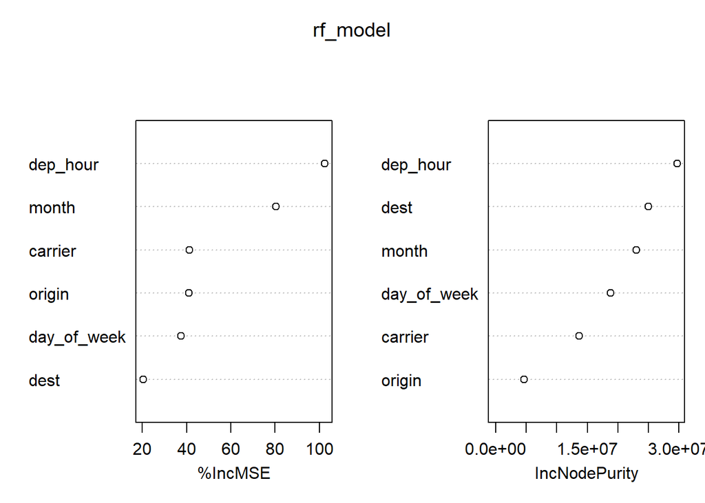

```r
varImpPlot(rf_model)
```

# **Conclusion**

```r
cat("### Conclusion:\n",
    "- The Random Forest model captures complex relationships in flight delay data.\n",
    "- Performance metrics indicate moderate predictive power, suggesting room for improvement.\n",
    "- Additional predictors such as weather conditions and aircraft type could enhance accuracy.\n",
    "- Future models will explore Gradient Boosting Machines (GBM) and Neural Networks for further optimization.")
```

```
## ### Conclusion:
##  - The Random Forest model captures complex relationships in flight delay data.
##  - Performance metrics indicate moderate predictive power, suggesting room for improvement.
##  - Additional predictors such as weather conditions and aircraft type could enhance accuracy.
##  - Future models will explore Gradient Boosting Machines (GBM) and Neural Networks for further optimization.
```

## **Interpretation of Feature Importance**:

1. **Departure Hour (dep_hour) is the most significant factor**
- The time of day significantly impacts flight delays, likely due to airport congestion during peak hours.
2. **Month (month) also plays a major role**
- Seasonal effects, holidays, and weather conditions in different months affect flight delays.
3. **Day of the Week (day_of_week) has moderate importance**
- Certain days (e.g., weekends vs. weekdays) may have different traffic patterns, impacting delays.
4. **Carrier (carrier) and Airport (origin, dest) also contribute.**
- Some airlines perform better at managing schedules, and particular airports experience more congestion.

Model Type: Random Forest Regression

- Type: Supervised Learning – Regression
- Algorithm: Random Forest
- Use Case: Predicting continuous numerical values (departure delay in minutes)

Why Random Forest?

- **Ensemble Learning Approach:**

Combines multiple decision trees to improve accuracy and reduce overfitting.

- Handles Non-Linearity: Captures complex relationships between input variables and output.
- **Feature Importance Measurement:** Identifies which factors (e.g., departure time, airport, airline) have the most influence on delays.
- **Inputs (Independent Variables):**
  - *dep_hour:* Departure hour
  - *month:* Month of the year
  - *day_of_week:* Day of the week
  - *origin:* Departure airport
  - *dest:* Destination airport
  - *carrier:* Airline code
  - *Output (Dependent Variable):*
  - *dep_delay:* Predicted departure delay in minutes

**Performance Metrics Used**:

- *Mean Absolute Error (MAE):* Measures the average magnitude of errors.
- *Root Mean Squared Error (RMSE):* Penalizes large errors more than MAE.
- *R-squared (R2):* Measures how well the model explains variance in flight delays.

# **14. Conclusion:**

This study analyzed flight delays using historical airline data and machine learning techniques to predict departure delays. The Random Forest Regression Model was implemented to evaluate key factors influencing delays. The model identified departure hour, month, and airport factors as the most important predictors. However, the model’s predictive power is currently low (R2 = 0.09), indicating that additional variables such as weather conditions, air traffic congestion, and aircraft type need to be incorporated.

**Key Findings:**

- Departure time significantly affects delays, likely due to congestion during peak hours.
- Certain airports experience more frequent delays due to operational inefficiencies.
- Airline performance varies, affecting delays differently based on scheduling efficiency.
- Machine learning models can be used, but additional features are necessary to improve accuracy.